# Data Preprocessing

# Preprocess data with `recipes`

## The New York City Flight Data

```r
library(tidymodels)
library(nycflights13)
library(skimr)
set.seed(123)
```

```r
flight_data <- flights |>
  mutate(
    arr_delay = ifelse(arr_delay >= 30, "late", "on_time"),
    arr_delay = factor(arr_delay),
    date = lubridate::as_date(time_hour)
  ) |>
  inner_join(weather, by = c("origin", "time_hour")) |>
  select(dep_time, flight, origin, dest, air_time, distance,
         carrier, date, arr_delay, time_hour) |>
  na.omit() |>
  mutate_if(is.character, as.factor)

flight_data %>%
  count(arr_delay) %>%
  mutate(prop = scales::percent(n/sum(n)))
```

```
# A tibble: 2 × 3
  arr_delay      n prop
  <fct>      <int> <chr>
1 late       52540 16%
2 on_time   273279 84%
```

```r
# glimpse(flight_data)
```

```r
flight_data %>%
  skimr::skim(dest, carrier)
# 16 carriers and 104 destinations

# take note! seems useful for work
```

[output not shown]

## Data Splitting with `rsample`

```r
set.seed(222)

data_split <- initial_split(flight_data, prop = 3/4)

train_data <- training(data_split)
test_data <- testing(data_split)
```

## Create Recipes, Roles and Features

- Create a recipe for new predictors and preprocessing
- `recipe()` outcome on the left hand side of the tilde, and predictors on the right hand side (by name or `.` for “all”). Also name the data set.
- `update_roles()`: optionally describe the roles of variables (like identification variables)
- Date features:
  - Normal date-column in R-date-format will be transformed in some kind of numeric type. This might be useful if there might be a linear trend between log-odds of a late arrival and the numeric date
  - Derive other meaningful features from the date like the day of week (“dow”), month, holiday
- Dummies for nominal predictors if needed
- Remove zero variance predictors (might also be produced by creating dummy variables) with `step_zv()`

```r
flights_rec <-
  recipe(arr_delay ~ ., data = train_data) |>
  update_role(flight, time_hour, new_role = "ID") |>
  step_date(date, features = c("dow", "month")) |>
  step_holiday(date,
               holidays = timeDate::listHolidays("US"),
               keep_original_cols = FALSE) |>
  step_rm(dest) |>
  step_dummy(all_nominal_predictors()) |>
  step_zv(all_predictors())

flights_rec
```

```
── Recipe ──────────────────────────────────────────────────────────────────────
```

```
── Inputs
```

```
Number of variables by role
```

```
outcome:   1
predictor: 7
ID:        2
```

```
── Operations
```

```
• Date features from: date
```

```
• Holiday features from: date
```

```
• Variables removed: dest
```

```
• Dummy variables from: all_nominal_predictors()
```

```
• Zero variance filter on: all_predictors()
```

## Fit a Model with a recipe

- Build a model specification with `parsnip`
- Create a model workflow to simplify the process of fitting a model with a recipe

```r
lr_mod <-
  logistic_reg() |>
  set_engine("glm")

flights_workflow <-
  workflow() |>
  add_model(lr_mod) |>
  add_recipe(flights_rec)

flights_fit <-
  flights_workflow |>
  fit(data = train_data)

flights_fit |>
  extract_fit_parsnip() |>
  tidy()
```

```
# A tibble: 56 × 5
   term                         estimate std.error statistic  p.value
   <chr>                           <dbl>     <dbl>     <dbl>    <dbl>
 1 (Intercept)                   5.36    0.0496       108.   0
 2 dep_time                     -0.00161 0.0000137   -118.   0
 3 air_time                     -0.0396  0.000526     -75.3  0
 4 distance                      0.00505 0.0000687     73.4  0
 5 date_USChristmasDay           1.35    0.177          7.60 3.04e-14
 6 date_USColumbusDay            0.736   0.170          4.33 1.51e- 5
 7 date_USCPulaskisBirthday      0.830   0.139          5.96 2.48e- 9
 8 date_USDecorationMemorialDay  0.583   0.117          4.98 6.38e- 7
 9 date_USElectionDay            0.958   0.190          5.04 4.55e- 7
10 date_USGoodFriday             1.28    0.167          7.64 2.23e-14
# ℹ 46 more rows
```

## Predict

- Create new predictions from the test data using `predict()`. `type = "prob"` for predicted class probabilities
- `augment()` for model and test data in one output
- ROC curve as performance metric with `roc_curve()` and area under the curve `roc_auc()` from the `yardstick` package

```r
#predict(flights_fit, test_data)
flights_aug <-
  augment(flights_fit, test_data)

# The data look like:
flights_aug %>%
  select(arr_delay, time_hour, flight, .pred_class, .pred_on_time)
```

```
# A tibble: 81,455 × 5
   arr_delay time_hour           flight .pred_class .pred_on_time
   <fct>     <dttm>               <int> <fct>               <dbl>
 1 on_time   2013-01-01 05:00:00   1545 on_time             0.943
 2 on_time   2013-01-01 05:00:00   1714 on_time             0.946
 3 on_time   2013-01-01 06:00:00    507 on_time             0.969
 4 on_time   2013-01-01 06:00:00   5708 on_time             0.958
 5 on_time   2013-01-01 06:00:00     71 on_time             0.963
 6 on_time   2013-01-01 06:00:00    194 on_time             0.974
 7 on_time   2013-01-01 06:00:00   1124 on_time             0.965
 8 on_time   2013-01-01 05:00:00   1806 on_time             0.974
 9 on_time   2013-01-01 06:00:00   1187 on_time             0.927
10 on_time   2013-01-01 06:00:00   4650 on_time             0.945
# ℹ 81,445 more rows
```

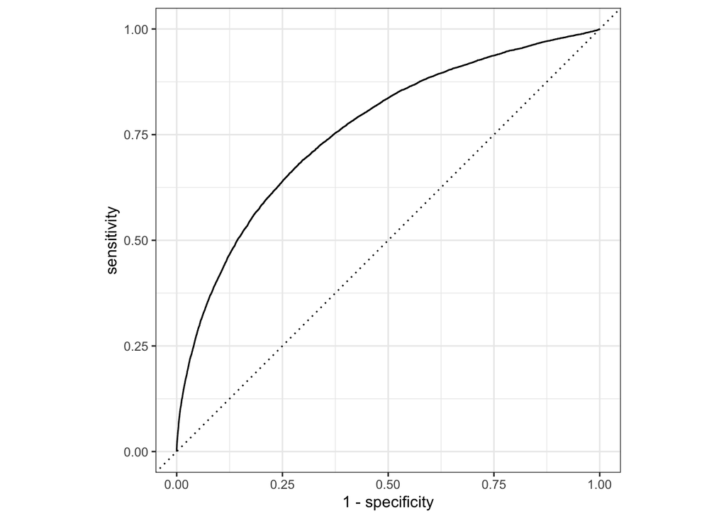

```r
flights_aug %>%
  roc_curve(truth = arr_delay, .pred_late) %>%
  autoplot()
```

```r
flights_aug %>%
  roc_auc(truth = arr_delay, .pred_late)
```

```
# A tibble: 1 × 3
  .metric .estimator .estimate
  <chr>   <chr>          <dbl>
1 roc_auc binary         0.761
```